# Wielowymiarowe metody statystyczne

Łukasz Wawrowski

3 10 2019

# Korelacje

Pierwszym krokiem jest wczytanie pakietów oraz danych.

```r
library(tidyverse)
library(haven)

psycho <- read_sav("data/poz_sop.sav")
```

Następnie, z racji tego, że nazwy zmiennych są zapisane w różny sposób stosujemy funkcję `clean_names()` z pakietu *janitor*.

```r
psycho <- janitor::clean_names(psycho)
```

## Cechy jakościowe

Chcąc przeprowadzić analizę korelacji cech jakościowych potrzebne są dwie takie cechy, podczas gdy w zbiorze danych jest tylko jedna - płeć. Tworzymy zatem drugą cechę na podstawie zmiennej *ps* przyjmując medianę jako punkt podziału. Do przekształcenia zmiennej ilościowej w jakościową służy funkcja `cut()`.

```r
psycho <- psycho %>%
  mutate(ps_mediana=cut(x = ps,
                        breaks = c(1,median(ps),5), # granice przedziałów
                        include.lowest = TRUE, # minimum w pierwszym
                        right = TRUE, # prawe przedziały domknięte
                        labels = c("niskie ps", "wysokie ps"))) %>% # etykiety
  mutate(plec=as.character(plec),
         plec2=recode(plec, `1` = "K", `2` = "M"))
```

Dodatkowo przekodowaliśmy wartości cechy płeć. Za pomocą funkcji `summary()` można sprawdzić jakie wartości przyjmuje cecha po przekształceniu:

```r
summary(psycho$ps_mediana)
```

```
##  niskie ps wysokie ps
##        368        328
```

Identyczny efekt uzyskamy stosując funkcję `table()`.

```r
table(psycho$ps_mediana) # częstość
```

```
##
##  niskie ps wysokie ps
##        368        328
```

Natomiast do tej funkcji można także dodać po przecinku drugą cechę, co spowoduje stworzenie tablicy krzyżowej.

```r
table(psycho$ps_mediana, psycho$plec2)
```

```
##
##                K   M
##   niskie ps  313  55
##   wysokie ps 284  44
```

Na tej podstawie można przeprowadzić test niezależności $\chi^2$ wykorzystując funkcję `chisq.test()` i podając jako argument tablicę krzyżową.

```r
chisq.test(table(psycho$ps_mediana, psycho$plec2))
```

```
##
##  Pearson's Chi-squared test with Yates' continuity correction
##
## data:  table(psycho$ps_mediana, psycho$plec2)
## X-squared = 0.21951, df = 1, p-value = 0.6394
```

Domyślnie uwzględniana jest poprawka na nieciągłość Yatesa, która ma znaczenie przy małych liczebnościach. Natomiast jeśli wartości w tablicy krzyżowej przekraczają wartość 5 to nie należy jej stosować.

```r
chisq.test(table(psycho$ps_mediana, psycho$plec2), correct = FALSE)
```

```
##
##  Pearson's Chi-squared test
##
## data:  table(psycho$ps_mediana, psycho$plec2)
## X-squared = 0.33318, df = 1, p-value = 0.5638
```

Podobny efekt uzyskamy wywołując funkcję `summary()` na tablicy krzyżowej.

```r
summary(table(psycho$ps_mediana, psycho$plec2))
```

```
## Number of cases in table: 696
## Number of factors: 2
## Test for independence of all factors:
##  Chisq = 0.3332, df = 1, p-value = 0.5638
```

Biorąc pod uwagę wartość p nie ma podstaw do odrzucenia hipotezy zerowej.

## Cechy ilościowe

Funkcja `cor()` służy do obliczenia wartości współczynnika korelacji. Zastosowanie jej na całym zbiorze spowoduje uzyskanie błędu ze względu na obecność zmiennych nienumerycznych.

```r
cor(psycho)
```

```
## Error in cor(psycho): 'x' must be numeric
```

Aby przeprowadzić obliczenia trzeba ograniczyć zbiór danych do cech numerycznych.

```r
korelacje <- psycho %>%
  select(wiek:refleksja) %>% # wybór cech numerycznych
  cor() %>% # obliczenie korelacji
  round(., 3) # zaokrąglenie do 3 miejsc po przecinku
```

W ten sposób otrzymaliśmy macierz korelacji, którą można w wizualny sposób przedstawić z wykorzystaniem pakietu *corrplot*.

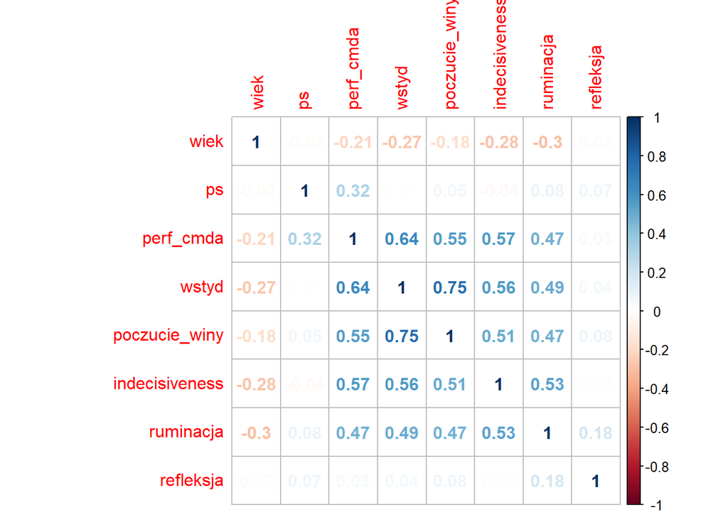

```r
library(corrplot)

corrplot(korelacje, method = "number")
```

Dodając kolejne argumenty do funkcji `corrplot()` możemy zmieniać wygląd tego wykresu, np. przedstawiając go w skali szarości.

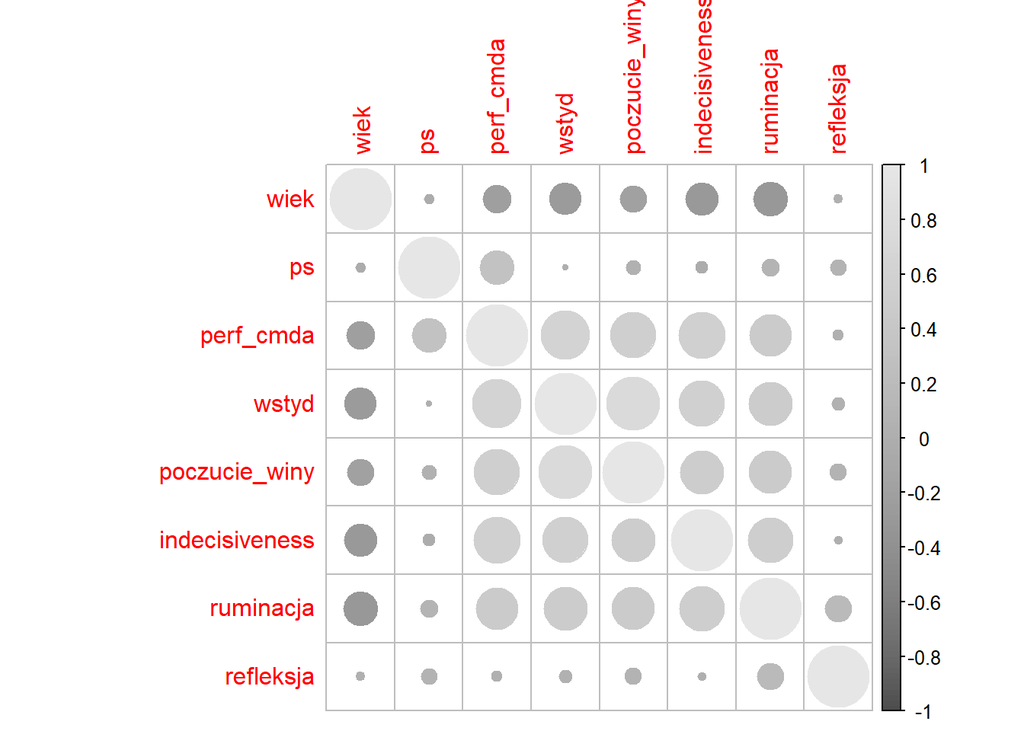

```r
corrplot(korelacje, col = gray.colors(100))
```

Inną modyfikacją może być uwzględnienie tylko istotnych korelacji na podstawie wartości p.

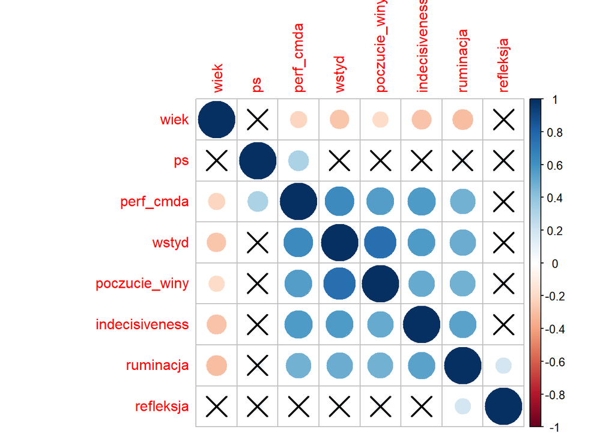

```r
istotnosci <- psycho %>%
  select(wiek:refleksja) %>%
  cor.mtest()

wartosci_p <- istotnosci$p

corrplot(korelacje, p.mat = wartosci_p, sig.level = 0.01)
```

Pełna lista możliwych modyfikacji znajduje się na [stronie pakietu](https://cran.r-project.org/web/packages/corrplot/vignettes/corrplot-intro.html).

Z kolei wykorzystując pakiet *apaTables* możliwe jest przedstawienie tych korelacji w formie tabeli APA eksportowanego do pliku word.

```r
library(apaTables)

apa.cor.table(psycho, "psycho_cortab.doc")
```

```
##
##
## Means, standard deviations, and correlations with confidence intervals
##
##
##   Variable          M     SD    1            2           3
##   1. wiek           26.74 7.56
##
##   2. ps             3.40  0.70  -.03
##                                 [-.10, .05]
##
##   3. perf_cmda      2.69  0.79  -.21**       .32**
##                                 [-.28, -.14] [.25, .38]
##
##   4. wstyd          15.45 7.13  -.27**       .01         .64**
##                                 [-.34, -.20] [-.07, .08] [.59, .68]
##
##   5. poczucie_winy  10.02 4.31  -.18**       .05         .55**
##                                 [-.25, -.11] [-.02, .13] [.50, .60]
##
##   6. indecisiveness 39.16 11.19 -.28**       -.04        .57**
##                                 [-.35, -.21] [-.11, .04] [.52, .62]
##
##   7. ruminacja      20.48 5.16  -.31**       .08*        .47**
##                                 [-.37, -.24] [.01, .15]  [.41, .53]
##
##   8. refleksja      21.58 4.81  .02          .07         .03
##                                 [-.05, .10]  [-.01, .14] [-.04, .11]
##
##   4           5          6           7
##
##
##
##
##
##
##
##
##
##
##
##   .75**
##   [.72, .78]
##
##   .56**       .51**
##   [.51, .61]  [.45, .56]
##
##   .49**       .47**      .53**
##   [.43, .55]  [.41, .53] [.48, .58]
##
##   .05         .07*       .02         .19**
##   [-.03, .12] [.00, .15] [-.06, .09] [.11, .26]
##
##
## Note. M and SD are used to represent mean and standard deviation, respectively.
## Values in square brackets indicate the 95% confidence interval.
## The confidence interval is a plausible range of population correlations
## that could have caused the sample correlation (Cumming, 2014).
## * indicates p < .05. ** indicates p < .01.
##
```

# ANOVA

W analizie wariancji wykorzystamy symbol tyldy `~`, który w R oznacza zależność. Za pomocą funkcji `aov()` sprawdzimy czy poziom wstydu różni się w zależności od płci.

```r
aov(wstyd ~ plec, data = psycho)
```

```
## Call:
##    aov(formula = wstyd ~ plec, data = psycho)
##
## Terms:
##                     plec Residuals
## Sum of Squares     46.72  35273.65
## Deg. of Freedom        1       694
##
## Residual standard error: 7.129277
## Estimated effects may be unbalanced
```

W tym wyniku nie otrzymujemy jednak informacji o istotności statystycznej. Aby wzbogacić ten raport musimy wywołać dodatkowo funkcję `summary()`.

```r
summary(aov(wstyd ~ plec, data = psycho))
```

```
##              Df Sum Sq Mean Sq F value Pr(>F)
## plec          1     47   46.72   0.919  0.338
## Residuals   694  35274   50.83
```

W przypadku analizy wariancji wygodnie jest przypisać wynik funkcji `aov()` do obiektu, ponieważ może on być później wykorzystany w różnych kontekstach - teście post-hoc albo tabeli.

```r
aov_wstyd_plec <- aov(wstyd ~ plec, data = psycho)
summary(aov_wstyd_plec)
```

```
##              Df Sum Sq Mean Sq F value Pr(>F)
## plec          1     47   46.72   0.919  0.338
## Residuals   694  35274   50.83
```

Test post-hoc Tukeya.

```r
TukeyHSD(aov_wstyd_plec)
```

```
##   Tukey multiple comparisons of means
##     95% family-wise confidence level
##
## Fit: aov(formula = wstyd ~ plec, data = psycho)
##
## $plec
##           diff       lwr      upr     p adj
## 2-1 -0.7417009 -2.260679 0.777277 0.3380429
```

Tabela APA z wynikami ANOVA.

```r
apa.aov.table(aov_wstyd_plec, "aov.doc")
```

```
##
##
## ANOVA results using wstyd as the dependent variable
##
##
##    Predictor        SS  df        MS       F    p partial_eta2
##  (Intercept) 144539.64   1 144539.64 2843.78 .000
##         plec     46.72   1     46.72    0.92 .338          .00
##        Error  35273.65 694     50.83
##  CI_90_partial_eta2
##
##          [.00, .01]
##
##
## Note: Values in square brackets indicate the bounds of the 90% confidence interval for partial eta-squared
```

# Regresja liniowa

Metody regresji będziemy aplikować na oryginalnym zbiorze danych, zatem wczytamy go jeszcze raz.

```r
library(tidyverse)
library(haven)

psycho <- read_sav("data/poz_sop.sav")
psycho <- janitor::clean_names(psycho)
```

W przypadku cech jakościowych R automatycznie zamienia je na cechy zerojedynkowe. Jedyne wymaganie to typ takiej cechy - powinien to być *faktor*.

```r
psycho <- psycho %>%
  mutate(plec=as.factor(plec))
```

Za estymację modelu liniowego odpowiada funkcja `lm()` (akronim *linear model*). Wstawiając znak `.` w postaci modelu brane pod uwagę są wszystkie cechy ze zbioru.

```r
model <- lm(indecisiveness ~ ., data = psycho)
summary(model)
```

```
##
## Call:
## lm(formula = indecisiveness ~ ., data = psycho)
##
## Residuals:
##     Min      1Q  Median      3Q     Max
## -33.332  -4.903  -0.096   4.980  29.321
##
## Coefficients:
##               Estimate Std. Error t value Pr(>|t|)
## (Intercept)   23.96402    2.65305   9.033  < 2e-16 ***
## plec2         -1.01833    0.89113  -1.143  0.25354
## wiek          -0.12476    0.04346  -2.871  0.00422 **
## ps            -2.88541    0.47818  -6.034 2.61e-09 ***
## perf_cmda      5.17835    0.56993   9.086  < 2e-16 ***
## wstyd          0.16692    0.07447   2.241  0.02533 *
## poczucie_winy  0.26638    0.11067   2.407  0.01635 *
## ruminacja      0.54034    0.07491   7.213 1.45e-12 ***
## refleksja     -0.08201    0.06588  -1.245  0.21362
## ---
## Signif. codes:  0 '***' 0.001 '**' 0.01 '*' 0.05 '.' 0.1 ' ' 1
##
## Residual standard error: 8.087 on 687 degrees of freedom
## Multiple R-squared:  0.4835, Adjusted R-squared:  0.4775
## F-statistic: 80.39 on 8 and 687 DF,  p-value: < 2.2e-16
```

Funkcjonalność R w kontekście modeli liniowych można rozszerzyć wykorzystując pakiet *olsrr*. Wszystkie funkcje z tego pakietu mają przyrostek `ols`. Funkcja `ols_regress` wyświetla szczegółowy i elegancki opis parametrów modelu.

```r
library(olsrr)

ols_regress(model)
```

```
##                         Model Summary
## --------------------------------------------------------------
## R                       0.695       RMSE                8.087
## R-Squared               0.483       Coef. Var          20.653
## Adj. R-Squared          0.477       MSE                65.397
## Pred R-Squared          0.468       MAE                 6.204
## --------------------------------------------------------------
##  RMSE: Root Mean Square Error
##  MSE: Mean Square Error
##  MAE: Mean Absolute Error
##
##                                 ANOVA
## ----------------------------------------------------------------------
##                  Sum of
##                 Squares         DF    Mean Square      F         Sig.
## ----------------------------------------------------------------------
## Regression    42056.866          8       5257.108    80.387    0.0000
## Residual      44927.954        687         65.397
## Total         86984.820        695
## ----------------------------------------------------------------------
##
##                                    Parameter Estimates
## ------------------------------------------------------------------------------------------
##         model      Beta    Std. Error    Std. Beta      t        Sig      lower     upper
## ------------------------------------------------------------------------------------------
##   (Intercept)    23.964         2.653                  9.033    0.000    18.755    29.173
##         plec2    -1.018         0.891       -0.032    -1.143    0.254    -2.768     0.731
##          wiek    -0.125         0.043       -0.084    -2.871    0.004    -0.210    -0.039
##            ps    -2.885         0.478       -0.182    -6.034    0.000    -3.824    -1.947
##     perf_cmda     5.178         0.570        0.366     9.086    0.000     4.059     6.297
##         wstyd     0.167         0.074        0.106     2.241    0.025     0.021     0.313
## poczucie_winy     0.266         0.111        0.103     2.407    0.016     0.049     0.484
##     ruminacja     0.540         0.075        0.249     7.213    0.000     0.393     0.687
##     refleksja    -0.082         0.066       -0.035    -1.245    0.214    -0.211     0.047
## ------------------------------------------------------------------------------------------
```

Podobny wynik można uzyskać z wykorzystaniem pakietu *apaTables* - od razu w formacie .doc.

```r
apa.reg.table(model, filename = "regresja.doc")
```

```
##
##
## Regression results using indecisiveness as the criterion
##
##
##      Predictor       b       b_95%_CI sr2  sr2_95%_CI             Fit
##    (Intercept) 23.96** [18.75, 29.17]
##          plec2   -1.02  [-2.77, 0.73] .00 [-.00, .00]
##           wiek -0.12** [-0.21, -0.04] .01 [-.00, .01]
##             ps -2.89** [-3.82, -1.95] .03  [.01, .05]
##      perf_cmda  5.18**   [4.06, 6.30] .06  [.04, .09]
##          wstyd   0.17*   [0.02, 0.31] .00 [-.00, .01]
##  poczucie_winy   0.27*   [0.05, 0.48] .00 [-.00, .01]
##      ruminacja  0.54**   [0.39, 0.69] .04  [.02, .06]
##      refleksja   -0.08  [-0.21, 0.05] .00 [-.00, .00]
##                                                           R2 = .483**
##                                                       95% CI[.43,.52]
##
##
## Note. A significant b-weight indicates the semi-partial correlation is also significant.
## b represents unstandardized regression weights.
## sr2 represents the semi-partial correlation squared.
## Square brackets are used to enclose the lower and upper limits of a confidence interval.
## * indicates p < .05. ** indicates p < .01.
##
```

Model ze wszystkimi zmiennymi nie jest najlepszym rozwiązaniem, więc należałoby poszukać modelu o lepszych własnościach. Pakiet *olsrr* umożliwia wyznaczenie wszystkich możliwych modeli.

```r
wszystkie_modele <- ols_step_all_possible(model)
glimpse(wszystkie_modele) # wyświetlenie struktury zbioru
```

```
## Observations: 255
## Variables: 14
## $ mindex     <int> 1, 2, 3, 4, 5, 6, 7, 8, 9, 10, 11, 12, 13, 14, 15, ...
## $ n          <int> 1, 1, 1, 1, 1, 1, 1, 1, 2, 2, 2, 2, 2, 2, 2, 2, 2, ...
## $ predictors <chr> "perf_cmda", "wstyd", "ruminacja", "poczucie_winy",...
## $ rsquare    <dbl> 0.3225068229, 0.3140202365, 0.2816809820, 0.2565693...
## $ adjr       <dbl> 3.215306e-01, 3.130318e-01, 2.806459e-01, 2.554981e...
## $ predrsq    <dbl> 0.317814722, 0.309648967, 0.277567062, 0.251858883,...
## $ cp         <dbl> 209.13216, 220.42015, 263.43452, 296.83549, 532.911...
## $ aic        <dbl> 5070.556, 5079.220, 5111.282, 5135.197, 5284.208, 5...
## $ sbic       <dbl> 3094.379, 3102.996, 3134.886, 3158.675, 3306.946, 3...
## $ sbc        <dbl> 5084.192, 5092.856, 5124.918, 5148.833, 5297.844, 5...
## $ msep       <dbl> 85.16060, 86.22736, 90.29239, 93.44891, 115.75907, ...
## $ fpe        <dbl> 85.15989, 86.22664, 90.29164, 93.44814, 115.75812, ...
## $ apc        <dbl> 0.6813980, 0.6899335, 0.7224592, 0.7477156, 0.92622...
## $ hsp        <dbl> 0.1225337, 0.1240687, 0.1299176, 0.1344594, 0.16656...
```

Na podstawie wartości wybranego kryterium można wybrać właściwy model.

```r
model_5zm <- lm(indecisiveness ~ wiek + ps + perf_cmda + wstyd + ruminacja, data = psycho)
```

Analiza współliniowości.

```r
ols_vif_tol(model_5zm)
```

```
## # A tibble: 5 x 3
##   Variables Tolerance   VIF
##   <chr>         <dbl> <dbl>
## 1 wiek          0.887  1.13
## 2 ps            0.837  1.20
## 3 perf_cmda     0.471  2.12
## 4 wstyd         0.504  1.98
## 5 ruminacja     0.688  1.45
```

Współczynnik tolerancji wskazuje na procent niewyjaśnionej zmienności danej zmiennej przez pozostałe zmienne objaśniające. Np. wiek w 89% nie jest wyjaśniony przez pozostałe zmienne w modelu. Z kolei współczynnik VIF jest obliczany na podstawie wartości współczynnika tolerancji (1/Tolerance) i wskazuje o ile wariancja szacowanego współczynnika regresji jest podwyższona z powodu współliniowości danej zmiennej objaśniającej z pozostałymi zmiennymi objaśniającymi. Wartość współczynnika VIF powyżej 4 należy uznać za wskazującą na współliniowość.

Sprawdzenie normalności reszt.

```r
ols_test_normality(model_5zm)
```

```
## -----------------------------------------------
##        Test             Statistic       pvalue
## -----------------------------------------------
## Shapiro-Wilk              0.9929         0.0021
## Kolmogorov-Smirnov        0.0326         0.4500
## Cramer-von Mises         51.4469          4e-04
## Anderson-Darling          0.8253         0.0330
## -----------------------------------------------
```

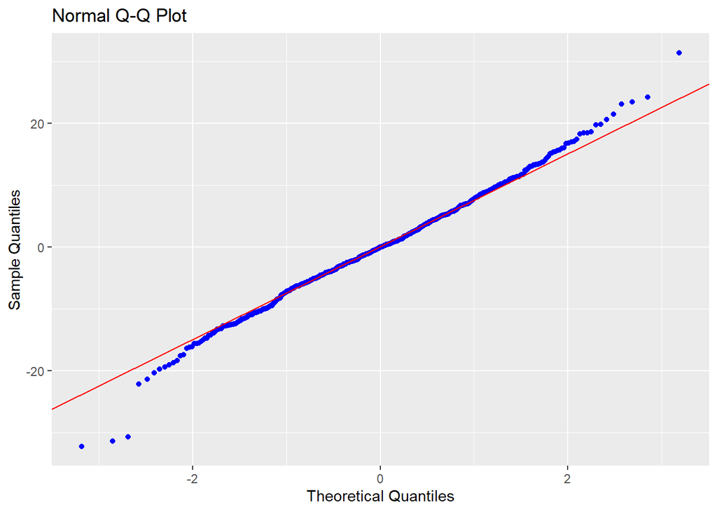

```r
ols_plot_resid_qq(model_5zm)
```

Identyfikacja wartości odstających z wykorzystaniem odległości Cooka.

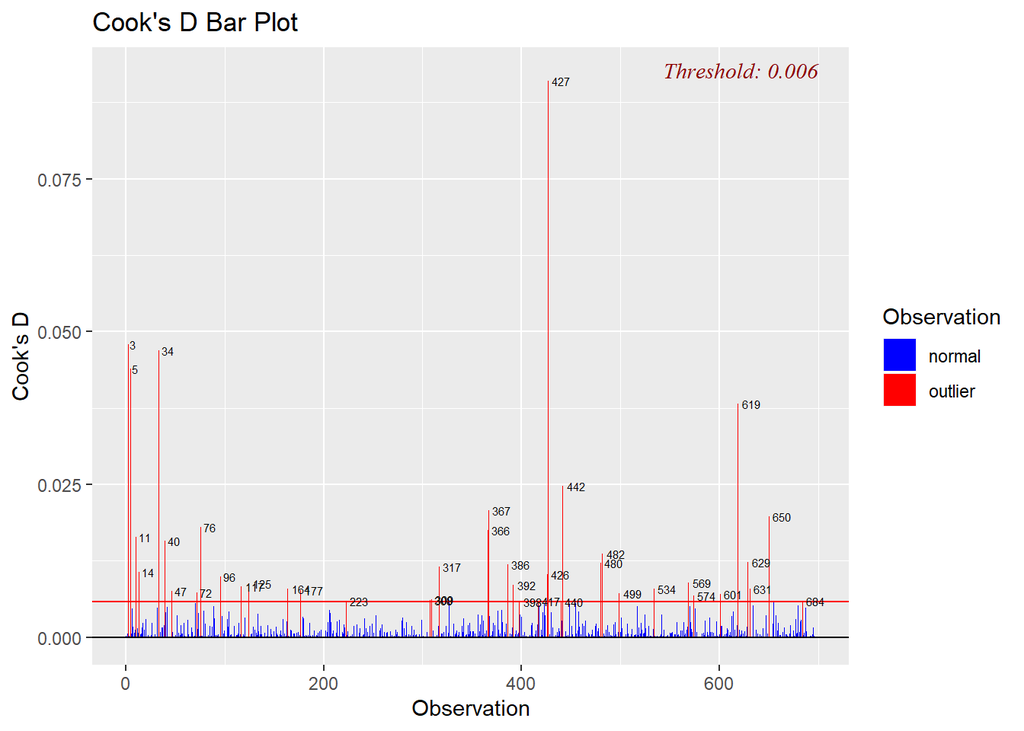

```r
ols_plot_cooksd_bar(model_5zm) # odległość cooka
```

Oraz reszt studentyzowanych. W celu ich eliminacji ze zbioru danych należy wynik działania funkcji przypisać do obiektu.

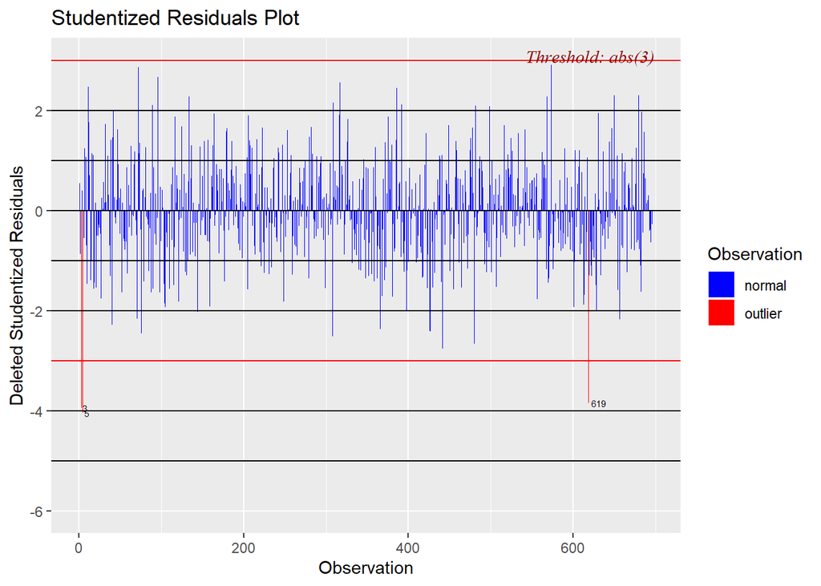

```r
dewianci <- ols_plot_resid_stud(model_5zm) # reszty studentyzowane
```

Następnie pobieramy numery tych obserwacji i usuwamy je ze zbioru tworząc nowy obiekt o nazwie `psycho2`.

```r
dewianci$outliers$observation
```

```
## [1]   3   5  34 367 619
```

```r
psycho2 <- psycho[-dewianci$outliers$observation,]
```

Nowy zbiór zawiera 691 obserwacji i wykorzystamy go do stworzenia nowego modelu - bez obserwacji odstających.

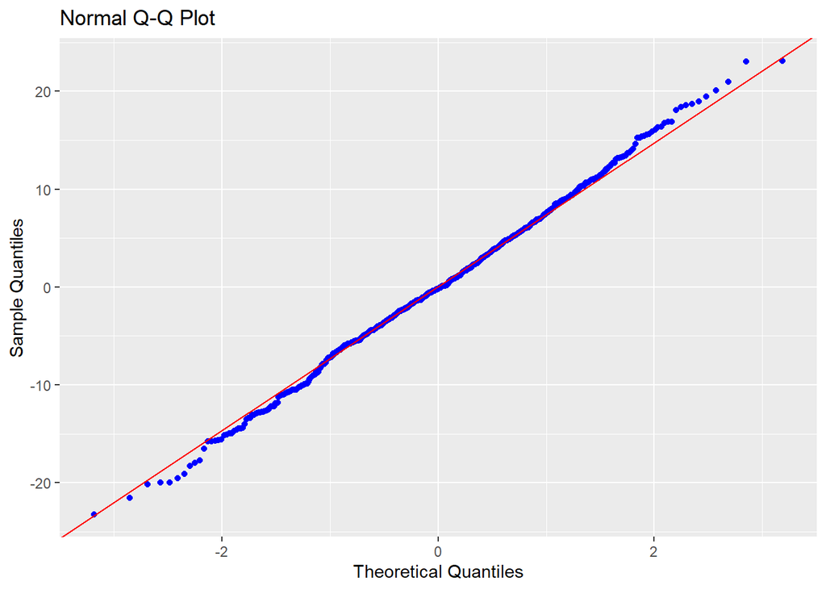

```r
model_5zm_dew <- lm(indecisiveness ~ wiek + ps + perf_cmda + wstyd + ruminacja, data = psycho2)
ols_plot_resid_qq(model_5zm_dew)
```

W tym przypadku wykres kwantyl-kwantyl wskazuje na znaczne podobieństwo do rozkładu normalnego.

Stworzymy jeszcze jeden model - z mniejszą liczbą predyktorów.

```r
model_4zm_dew <- lm(indecisiveness ~ wiek + ps + perf_cmda + ruminacja, data = psycho2)
```

Dwa lub więcej modeli można ze sobą porównać w tabeli APA. Trzeba jednak pamiętać, aby podać kolejne modele w odpowiedniej kolejności - od najmniejszej liczby predyktorów.

```r
apa.reg.table(model_4zm_dew, model_5zm_dew, filename = "reg2.doc")
```

```
##
##
## Regression results using indecisiveness as the criterion
##
##
##    Predictor       b       b_95%_CI  beta    beta_95%_CI sr2  sr2_95%_CI
##  (Intercept) 21.65** [16.99, 26.32]
##         wiek -0.13** [-0.21, -0.05] -0.09 [-0.14, -0.03] .01 [-.00, .02]
##           ps -3.45** [-4.33, -2.56] -0.22 [-0.27, -0.16] .04  [.02, .06]
##    perf_cmda  7.24**   [6.34, 8.15]  0.51   [0.45, 0.57] .18  [.14, .22]
##    ruminacja  0.65**   [0.51, 0.78]  0.30   [0.24, 0.36] .07  [.04, .09]
##
##
##
##  (Intercept) 20.13** [15.52, 24.73]
##         wiek  -0.10* [-0.18, -0.02] -0.07 [-0.12, -0.01] .00 [-.00, .01]
##           ps -2.84** [-3.74, -1.94] -0.18 [-0.24, -0.12] .03  [.01, .04]
##    perf_cmda  5.61**   [4.55, 6.68]  0.39   [0.32, 0.47] .07  [.05, .10]
##        wstyd  0.31**   [0.20, 0.43]  0.20   [0.13, 0.27] .02  [.01, .03]
##    ruminacja  0.56**   [0.43, 0.70]  0.26   [0.20, 0.32] .05  [.02, .07]
##
##
##
##       r             Fit        Difference
##
##  -.29**
##    -.03
##   .60**
##   .55**
##             R2 = .502**
##         95% CI[.45,.54]
##
##
##  -.29**
##    -.03
##   .60**
##   .59**
##   .55**
##             R2 = .523** Delta R2 = .020**
##         95% CI[.47,.56]  95% CI[.01, .03]
##
##
## Note. A significant b-weight indicates the beta-weight and semi-partial correlation are also significant.
## b represents unstandardized regression weights. beta indicates the standardized regression weights.
## sr2 represents the semi-partial correlation squared. r represents the zero-order correlation.
## Square brackets are used to enclose the lower and upper limits of a confidence interval.
## * indicates p < .05. ** indicates p < .01.
##
```

Innym narzędziem do porównywania parametrów jest pakiet *jtools*, który na wykresach przedstawia parametry modeli.

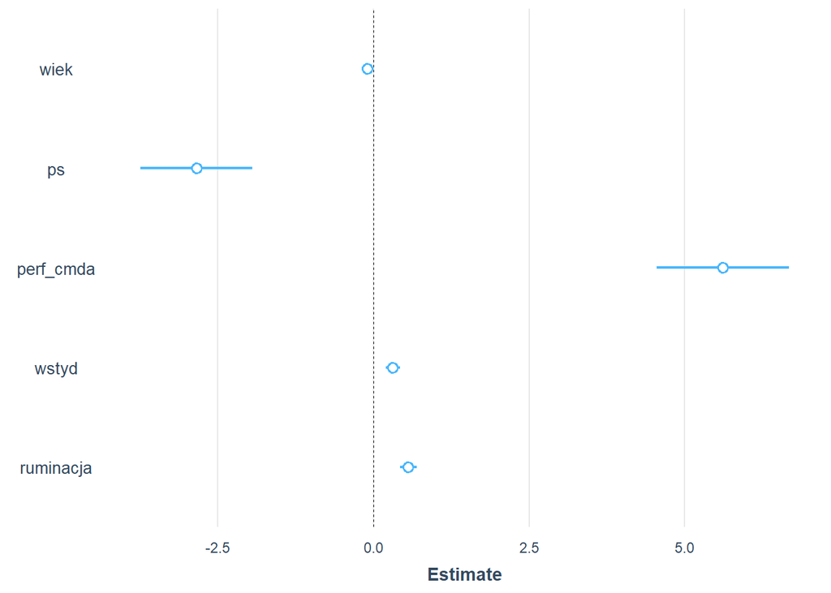

```r
library(jtools)

plot_summs(model_5zm_dew)
```

Można także uwzględnić większą liczbę modeli.

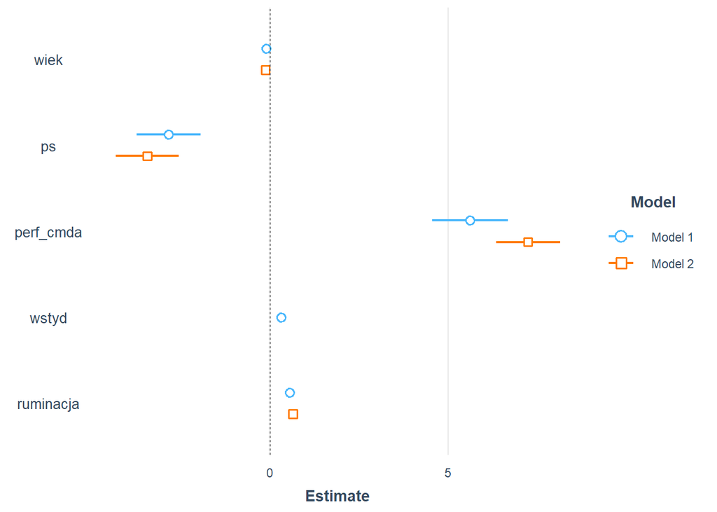

```r
plot_summs(model_5zm_dew, model_4zm_dew)
```

I dodając rozkład.

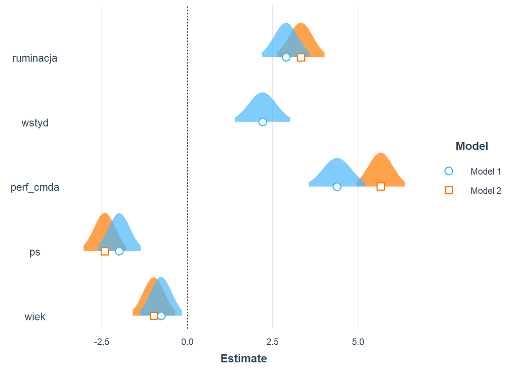

```r
plot_summs(model_5zm_dew, model_4zm_dew, scale = TRUE, plot.distributions = TRUE)
```

Pakiet ten ma też możliwość przedstawienie porównania modeli w formie tabelarycznej.

```r
export_summs(model_4zm_dew, model_5zm_dew,
             error_format = "[{conf.low}, {conf.high}]",
             ci_level = 0.95)
```

|  | Model 1 | Model 2 |
| --- | --- | --- |
| (Intercept) | 21.65 *** | 20.13 *** |
|  | [16.99, 26.32] | [15.52, 24.73] |
| wiek | -0.13 ** | -0.10 * |
|  | [-0.21, -0.05] | [-0.18, -0.02] |
| ps | -3.45 *** | -2.84 *** |
|  | [-4.33, -2.56] | [-3.74, -1.94] |
| perf_cmda | 7.24 *** | 5.61 *** |
|  | [6.34, 8.15] | [4.55, 6.68] |
| ruminacja | 0.65 *** | 0.56 *** |
|  | [0.51, 0.78] | [0.43, 0.70] |
| wstyd |  | 0.31 *** |
|  |  | [0.20, 0.43] |
| N | 691 | 691 |
| R2 | 0.50 | 0.52 |
| *** p < 0.001; ** p < 0.01; * p < 0.05. |  |  |

Wszystkich opcji dostosowania wyglądu raportu jest bardzo dużo - można skorzystać z instrukcji na [stronie](https://cran.r-project.org/web/packages/jtools/vignettes/summ.html) oraz z plików pomocy dla odpowiednich funkcji.

Kolejne modele regresji dopasujemy do danych standaryzowanych. W tym celu dokonujemy odpowiednich przekształceń.

```r
psycho_z <- psycho %>%
  select(-plec) %>% # usunięcie zmiennej płeć - nie może być standaryzowana
  rename(indec=indecisiveness) %>% # zmiana nazwy zmiennej
  standardize() %>% # standaryzacja wszystkich cech
  mutate(plec=psycho$plec, # powrót zmiennej płeć
         plec=ifelse(test = plec == 1, yes = 1, no = -1)) # rekodowanie zmiennej płeć
```

Poniżej zostały stworzone trzy modele, wykorzystujące różne operatory pomiędzy zmiennymi.

```r
model1 <- lm(indec ~ wiek + plec, data = psycho_z) # dwie zmienne
model2 <- lm(indec ~ wiek*plec, data = psycho_z) # dwie zmienne i interakcja
model3 <- lm(indec ~ wiek:plec , data = psycho_z) # tylko interakcja

export_summs(model1, model2, model3,
             model.names = c("M1", "M2", "M3"))
```

|  | M1 | M2 | M3 |
| --- | --- | --- | --- |
| (Intercept) | -0.07 | -0.06 | 0.01 |
|  | (0.05) | (0.05) | (0.04) |
| wiek | -0.28 *** | -0.22 *** |  |
|  | (0.04) | (0.05) |  |
| plec | 0.09 | 0.09 |  |
|  | (0.05) | (0.05) |  |
| wiek:plec |  | -0.08 | -0.25 *** |
|  |  | (0.05) | (0.04) |
| N | 696 | 696 | 696 |
| R2 | 0.08 | 0.09 | 0.06 |
| *** p < 0.001; ** p < 0.01; * p < 0.05. |  |  |  |